# InstaCart Exploratory Analysis: Users

April Leclair, Daniel Ochoa, Hoang Anh Thai Vu, Qiuhan Sun

This file provides some exploratory analysis regarding users in the InstaCart data.

# Setting Constants

```r
fillColor = "seagreen4"
```

# Reading In The Data

```r
orders <- read_csv("../Source/orders_sample40.csv") %>%
  mutate(order_dow = as.character(recode(order_dow, `0`="Sunday", `1`="Monday", `2`="Tuesday",
                            `3`="Wednesday", `4`="Thurday", `5`="Friday", `6`="Saturday")))
order_products <- read_csv("../Source/order_products_sample40.csv")
products <- read_csv("../Source/products.csv")
aisles <- read_csv("../Source/aisles.csv")
departments <- read_csv("../Source/departments.csv")
```

# Analyzing A User In Depth

We will begin with a randomly chosen user, perhaps not that interesting.

The maximum number of orders that any user can have is 100. We want as many data points as possible when we choose to evalute a specific user. Thus, we have limited out search to those users with 100 orders, there are 1374 of these.

Now we will randomly pick on of these users, we picked user_id = 29058

```r
user29058 <-
  orders %>%
  filter(user_id == 29058) %>%
  filter(eval_set == "prior") %>%
  mutate(order_hour_of_day = as.numeric(order_hour_of_day))
```

## Day of Week and Hour of Day Analysis

First lets look at which days this user mainly orders on.

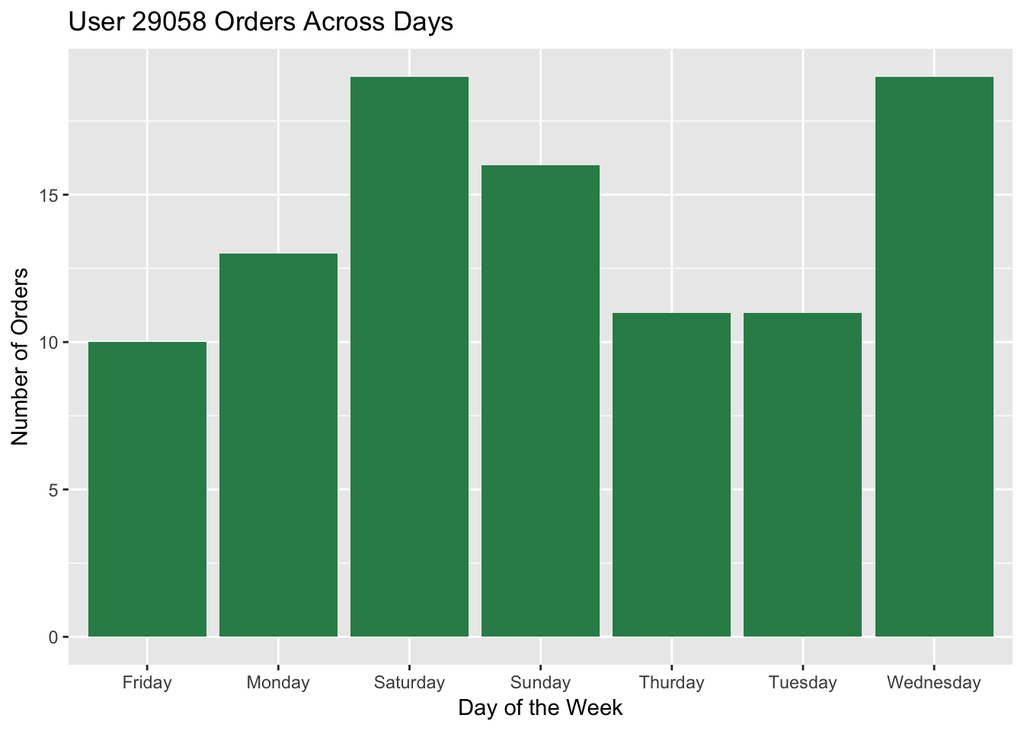

```r
user29058 %>%
  group_by(order_dow) %>%
  summarise(count = n()) %>%
  ggplot(aes(x=order_dow, y=count)) + geom_bar(stat="identity", fill=fillColor) + labs(title="User 29058 Orders Across Days", x="Day of the Week", y="Number of Orders")
```

It seems like this user has spaced out their orders across the week quite well, however Saturday and Wednesday are both hot days.

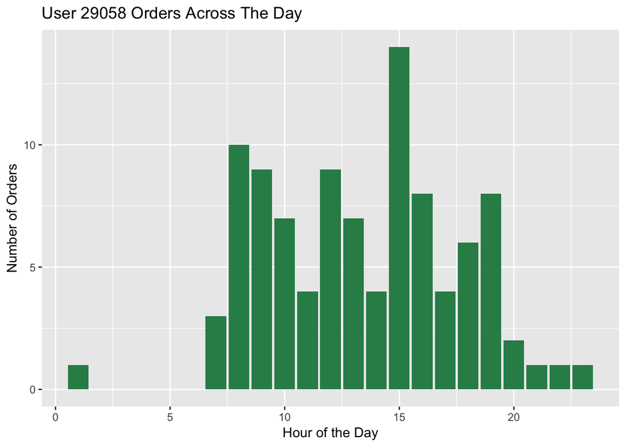

```r
user29058 %>%
  group_by(order_hour_of_day) %>%
  summarise(count = n()) %>%
  ggplot(aes(x=order_hour_of_day, y=count)) + geom_col(fill=fillColor) + labs(title="User 29058 Orders Across The Day", x="Hour of the Day", y="Number of Orders")
```

This user has also spaced their orders across the day quite well. Their ordering window seems to open at 8am and close at 7pm. This makes sense with what is expected from a typical user. However, the orders within this time are not evenly distributed, they seem to be peaks and valleys with orders being made most often at 3pm.

Finally, lets consider how ordering during the day is effected by which day of the week it is.

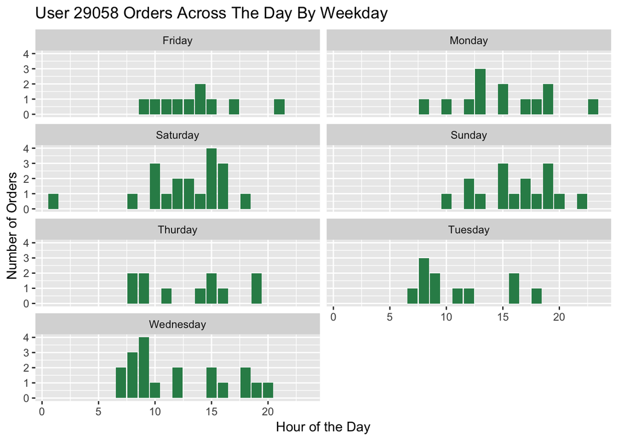

```r
user29058_hourOfDay <-
  user29058 %>%
  ggplot(aes(x=order_hour_of_day)) + geom_histogram(stat="count", fill=fillColor) + labs(title="User 29058 Orders Across The Day By Weekday", x="Hour of the Day", y="Number of Orders")
user29058_hourOfDay + facet_wrap( ~ order_dow, ncol=2)
```

From the above plots we can see that ordering trends do seem to differ from day to day. For instance, Wednesday orders tend to take place in the mornings while Sunday ordering tends to take place in the afternoon.

## Product Analysis

First we need to join the relevant tables.

```r
user29058 <-
  user29058 %>%
  left_join(order_products, by="order_id") %>%
  left_join(products, by="product_id") %>%
  left_join(departments, by="department_id") %>%
  left_join(aisles, by="aisle_id")
```

### Product Distribution By Count

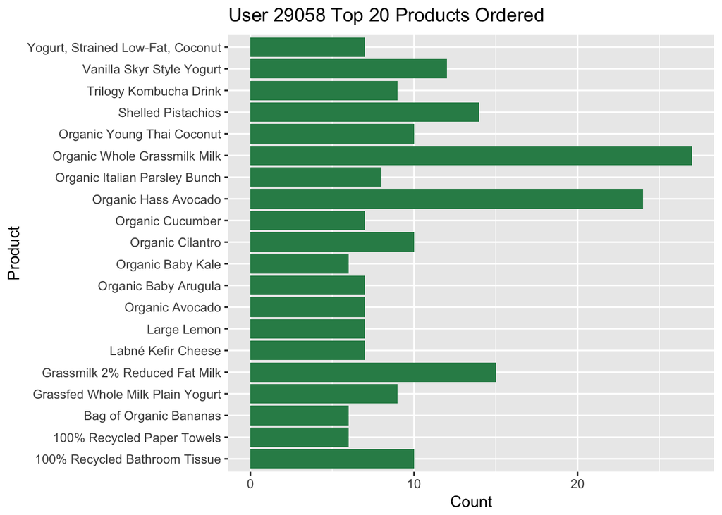

```r
user29058_top20Products <-
  user29058 %>%
  group_by(product_name) %>%
  summarise(count = n()) %>%
  arrange(desc(count)) %>%
  head(20)

ggplot(data = user29058_top20Products, aes(x=product_name, y=count)) + geom_col(fill=fillColor) + coord_flip() + labs(title="User 29058 Top 20 Products Ordered", x="Product", y="Count")
```

It seems like this user is particularly health concious, ordering mainly organic fruits and vegetables.

### Product Distribution By Department

First we are going to look at this user’s density distribution by department by time of day.

```r
user29058_Departments <-
  user29058 %>%
  group_by(department) %>%
  summarise(count = n()) %>%
  arrange(desc(count))
```

First lets look at the distribution of departments.

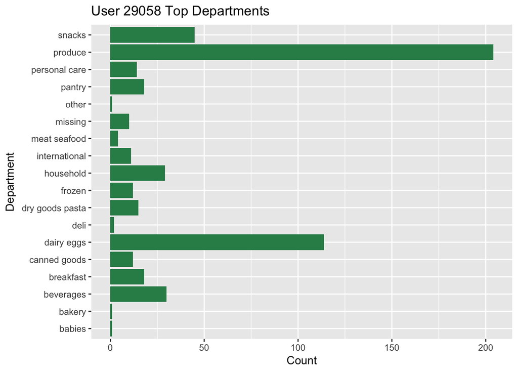

```r
ggplot(data=user29058_Departments, aes(x=department, y=count)) + geom_col(fill=fillColor) + coord_flip() + labs(title="User 29058 Top Departments", x="Department", y="Count")
```

Now how about the distribution of departments over the day?

We are going to want to filter out the departments without many total orders. We also don’t want out graph to be too cluttered so we’ll only consider the top 10 departments.

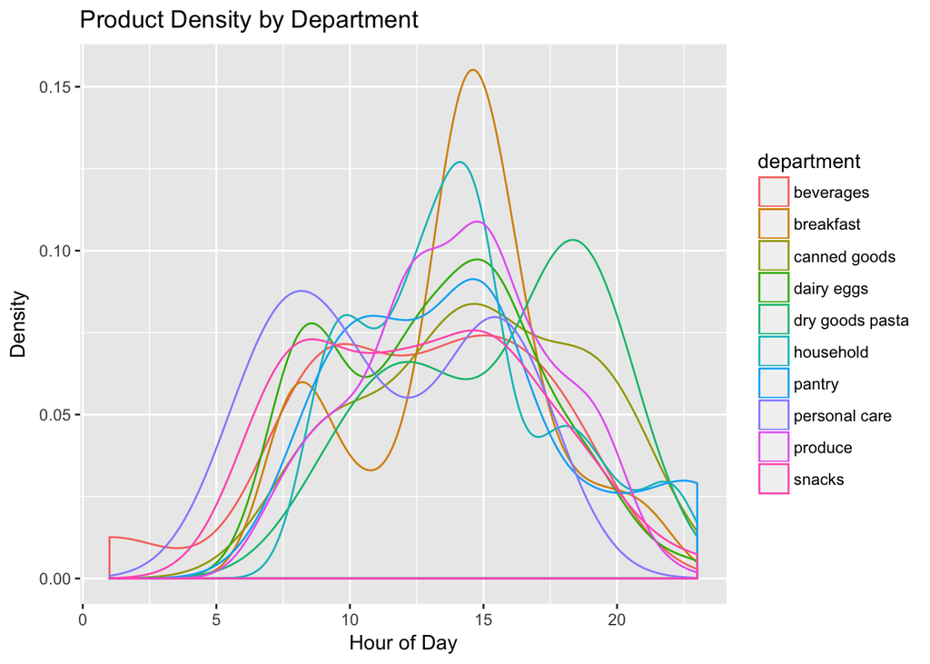

```r
user29058 %>%
  filter(department %in% head(user29058_Departments$department, 10)) %>%
  ggplot(aes(x=order_hour_of_day, group=department, colour=department)) + geom_density() + xlim(1,23) + labs(title="Product Density by Department", x="Hour of Day", y="Density")
```